# 06 Matrices

[figure not shown]

# Class Survey

Fill out the survey at this link! :)

https://forms.gle/E7sQc2URLSvkJcqu7

#### Unit 1: Vectors, Book ILA Ch. 1-5

#### Unit 2: Matrices, Book ILA Ch. 6-11 + Book IMC Ch. 2

- *06 Matrices*
- 07 Linear Equations
- 08 Linear Dynamical Systems
- 09 Matrix Multiplication
- 10 Matrix Inverse

#### Unit 3: Least Squares, Book ILA Ch. 12-14 + Book IMC Ch. 8

#### Unit 4: Eigen-decomposition, Book IMC Ch. 10, 12, 19

# Outline: 06 Matrices

- **Matrices**
- Matrix-vector multiplication
- Examples

# Matrices

$\color{#EF5645}{\text{Definition}}$: A matrix is a rectangular array of numbers, e.g.: $$A = \begin{bmatrix} 0 & 1 & -2.3 \\ 1.3 & 4 & -0.1 \end{bmatrix}$$

- Its size, or shape, is: (row dimension) x (column dimension).
  - $\color{#047C91}{\text{Example}}$: Matrix above has size 2 x 3.
- Its elements are called: entries, coefficients.
- $A_{i, j}$ refers to element at ith row and jth column in matrix $A$.
  - i is the row index and j is the column index.

$\color{#003660}{\text{In Python}}$, we use `numpy` and `np.array` to build matrices. The shape of the matrix can be accessed via the function `shape`.

```python
import numpy as np

A = np.array([
    [0, 1, -2.3],
    [1.3, 4, -0.1]
])
print(np.shape(A)); print(A.shape)
v = np.array([1, 2, 3, 4]); print(len(v))
```

```
(2, 3)
(2, 3)
4
```

$\color{#003660}{\text{In Python}}$, we can access the elements of the matrix.

```python
v = [1.1, 2.2, 3.3, 4.3]; #print(len(v))

for v_index in range(len(v)):
    print(v[v_index])

for v_value in v:
    print(v_value)
```

[output not shown]

```python
print(A); print(A[0][2]); print(A[0, 2])
# Implement code that prints all entries of the matrix A
print("Begin for loop:")
print(A.shape)
n_rows = A.shape[0]; n_columns = A.shape[1]
n_rows, n_columns = A.shape

for i in range(n_rows):
    for j in range(n_columns):
        print(A[i, j])
```

```
[[ 0.   1.  -2.3]
 [ 1.3  4.  -0.1]]
-2.3
-2.3
Begin for loop:
(2, 3)
0.0
1.0
-2.3
1.3
4.0
-0.1
```

# Sizes/Shapes of Matrices

$\color{#EF5645}{\text{Definitions}}$: A m x n matrix $A$ is:

- tall if m > n,
- wide if m < n,
- square if m = n.

```python
import numpy as np

A = np.array([
    [1, 2, 3],
    [4, 5, 6]
])
A.shape
```

```
(2, 3)
```

# Matrices, Vectors and Scalars

$\color{#EF5645}{\text{Definitions}}$:

- A 1 x 1 matrix is a number or scalar.
- A n x 1 matrix is an $n$-vector.
- A 1 x n matrix is a $n$-row-vector.

Starting now, we will distinguish vectors and row vectors.

# Columns and rows of a matrix

$\color{#EF5645}{\text{Notations}}$: Take $A$ a $m \times n$ matrix with entries $A_{ij}$ for $i=1, ..., m$ and $j=1..., n$.

- Its jth column is the $m$-vector: $$\begin{bmatrix} A_{1j} \\ \vdots \\ A_{mj} \end{bmatrix}$$
- Its ith row is the $n$-row-vector: $[A_{i1}, ..., A_{in}]$.

# Slices of a matrix

$\color{#EF5645}{\text{Definition}}$ The slice of matrix $A_{p:q, r:s}$ is the matrix: $$\begin{bmatrix} A_{pr} & A_{p, r+1} & ... & A_{ps} \\ ... & ... & ... & ... \\ A_{qr} & A_{q, r+1} & ... & A_{qs} \end{bmatrix}$$

$\color{#003660}{\text{In Python}}$, we can extract rows, columns and slices:

```python
A = np.array([[1, 2, 3], [4, 5, 6], [7, 8, 9]]); print("Matrix:"); print(A)
# print(A[0, :]); print(A[:, 1]); print(A[0, 1])

# 1, 2, 4, 5
A[0:(1+1), 1:(2+1)]
```

```
Matrix:
[[1 2 3]
 [4 5 6]
 [7 8 9]]
```

```
array([[2, 3],
       [5, 6]])
```

# Block matrices

$\color{#EF5645}{\text{Definition}}$: A matrix $A$ composed from other matrices is called a block matrix: $$A = \begin{bmatrix} B & C \\ D & E \end{bmatrix}$$ where $B, C, D, E$ are called submatrices or blocks of $A$.

# Column/row representations

$\color{#EF5645}{\text{Notations}}$: Take $A$ a $m \times n$ matrix with entries $A_{ij}$ for $i=1, ..., m$ and $j=1..., n$.

- $A$ is the block matrix of its columns $a_1, ..., a_n$:
  - $A = [a_1 ... a_n]$
- $A$ is the block matrix of its rows $b_1, ..., b_m$:
  - $A = \begin{bmatrix} b_1 \\ \vdots \\ b_m \end{bmatrix}.$

# Examples in ECE and beyond

- Images: $A_{ij}$ is intensity value at $i, j$.

$\color{#003660}{\text{In Python}}$, we can plot an image represented by a matrix.

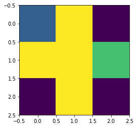

```python
A = np.array([[0.3, 1, 0],[1, 1, 0.7],[0, 1, 0]]); A
import matplotlib.pyplot as plt

plt.imshow(A, cmap="viridis");
#plt.axis("off")
```

# Examples in ECE and beyond

- Weather: $A_{ij}$ is rainfall data at location $i$ on day $j$.
- Finances: $A_{ij}$ is the return of asset $i$ in period $j$.

$\color{#047C91}{\text{Exercise}}$: In each of these, what do the rows and columns mean?

# Special Matrices

$\color{#EF5645}{\text{Definition}}$: The $m \times n$ zero matrix (resp. ones-matrix) is the matrix with all entries equal to $0$ (resp. to $1$).

$\color{#EF5645}{\text{Definition}}$: The identity matrix $I$ is the square matrix with $I_{ii} = 1$ and $I_{ij} = 0$ if $i\neq j$, for example: $$\begin{bmatrix} 1 & 0 \\ 0 & 1 \end{bmatrix}.$$

$\color{#003660}{\text{In Python}}$:

```python
zero_vec = np.zeros(4); print(zero_vec)
ones_vec = np.ones(5); print(ones_vec)
zero_mat = np.zeros((2, 3)); print(zero_mat) # 2 x 3
ones_mat = np.ones((2, 4)); print(ones_mat)  #2x4

identity_mat = np.identity(4); identity_mat
```

```
[0. 0. 0. 0.]
[1. 1. 1. 1. 1.]
[[0. 0. 0.]
 [0. 0. 0.]]
[[1. 1. 1. 1.]
 [1. 1. 1. 1.]]
```

```
array([[1., 0., 0., 0.],
       [0., 1., 0., 0.],
       [0., 0., 1., 0.],
       [0., 0., 0., 1.]])
```

# Diagonal Matrices

$\color{#EF5645}{\text{Definition}}$: A diagonal matrix $A$ is a square matrix with $A_{ij} = 0$ for $i \neq j$.

- diag$(a_1, ..., a_n)$ denotes the diagonal matrix with $A_{ii} = a_i$: $$\text{diag}(0.2, -3, 1.2) = \begin{bmatrix} 0.2 & 0 & 0 \\ 0 & -3 & 0 \\ 0 & 0 & 1.2 \end{bmatrix}$$

$\color{#003660}{\text{In Python}}$:

```python
np.diag(np.ones(7))
```

```
array([[1., 0., 0., 0., 0., 0., 0.],
       [0., 1., 0., 0., 0., 0., 0.],
       [0., 0., 1., 0., 0., 0., 0.],
       [0., 0., 0., 1., 0., 0., 0.],
       [0., 0., 0., 0., 1., 0., 0.],
       [0., 0., 0., 0., 0., 1., 0.],
       [0., 0., 0., 0., 0., 0., 1.]])
```

# Triangular Matrices

$\color{#EF5645}{\text{Definition}}$: A lower triangular matrix $A$ is a matrix such that $A_{ij} = 0$ for $i < j$. An upper triangular matrix $A$ is a matrix such that $A_{ij} = 0$ for $i > j$.

$\color{#047C91}{\text{Example}}$: $\begin{bmatrix} 0.2 & 1.2 & 10 \\ 0 & -3 & 0 \\ 0 & 0 & 1.2 \end{bmatrix}$ (upper-triangular)

# Transpose

$\color{#EF5645}{\text{Definition}}$: The transpose of an $m \times n$ matrix $A$ is written $A^T$ and is defined by: $$ (A^T)_{ij} = A_{ji}, \quad i = 1,..., n \quad j=1,...,m$$

$\color{#047C91}{\text{Example}}$: $\begin{bmatrix} 0.2 & 1.2 & 10 \\ 0 & -3 & 0 \end{bmatrix}^T = \begin{bmatrix} 0.2 & 0 \\ 1.2 & -3 \\ 10 & 0 \end{bmatrix}$

$\color{#003660}{\text{In Python}}$:

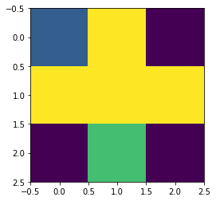

```python
#print(A); print(A.T)
plt.imshow(A.T);
```

# Addition, Substraction and Scalar Multiplication

Just like vectors:

- we can add or subtract matrices of the same size,
- we can multiply a matrix by a scalar.

$\color{#6D7D33}{\text{Property}}$: The transpose verifies:

- $(A^T)^T = A$.
- $(A + B)^T = A^T + B^T$.

# Matrix norm

$\color{#EF5645}{\text{Definition}}$: For a $m \times n$ matrix $A$, we define the matrix norm as: $$||A|| = \sqrt{\sum_{i=1}^m \sum_{j=1}^n A_{ij}^2}.$$

$\color{#EF5645}{\text{Remark}}$: This definition agrees with the definition of norm of vectors when $n=1$ or $m=1$.

$\color{#047C91}{\text{Exercise}}$: Compute the matrix norm of $A = \begin{bmatrix} 1 & 0 & -1\\ 0 & 1 & 1 \end{bmatrix}.$

$\color{#003660}{\text{In Python}}$, there are many ways to find the norm of a matrix.

```python
import numpy as np

A = np.array([[-1, 0., 2.], [0., 1., 0.]])
print(A); print(np.linalg.norm(A));
# print(A ** 2); print(np.sqrt(np.sum(A**2)))

norm = 0
n_rows, n_cols = A.shape
for i in range(n_rows):
    for j in range(n_cols):
        norm = norm + A[i, j] ** 2
norm = np.sqrt(norm); print(norm)
```

```
[[-1.  0.  2.]
 [ 0.  1.  0.]]
2.449489742783178
2.449489742783178
```

$\color{#EF5645}{\text{Remark}}$: As opposed to vectors which had 1 axis, matrices have several axes. Observe below how `numpy` functions adapt to the case of several axes.

```python
print(A)
print(np.sum(A))
print(np.sum(A, axis=0))
print(np.sum(A, axis=1))
```

```
[[-1.  0.  2.]
 [ 0.  1.  0.]]
2.0
[-1.  1.  2.]
[1. 1.]
```

# Distance between two matrices

$\color{#EF5645}{\text{Definition}}$: The distance between two matrices $A$ and $B$ is defined as: $$dist(A, B) = ||A - B||.$$

$\color{#EF5645}{\text{Remark}}$: This means that the clustering algorithm, which only needs a notion of "distance", works on the matrices.

# Outline: 06 Matrices

- Matrices
- **Matrix-vector multiplication**
- Examples

# Matrix-vector multiplication

$\color{#EF5645}{\text{Definition}}$: The matrix-vector multiplication $y$ of $m\times n$ matrix $A$ and $n$-vector $x$ is denoted $y = Ax$ and is defined as: $$y_i = A_{i1}x_1 + ... + A_{in}x_{n}, \quad i=1,...,m$$

$\color{#047C91}{\text{Exercise}}$: Let $I$ be the $n \times n$ identity matrix and $x$ an $n$-vector. Compute $Ix$.

$\color{#047C91}{\text{Exercise}}$: Let $0_n$ be the $n \times n$ zeroes matrix and $x$ an $n$-vector. Compute $0_nx$.

$\color{#047C91}{\text{Exercise}}$: Compute the matrix-vector multiplication of: $$A = \begin{bmatrix} 0 & 2 & -1 \\ -2 & 1 & 1 \end{bmatrix}; \quad v = \begin{bmatrix} 2 \\ 1 \\ -1 \end{bmatrix}$$

$\color{#003660}{\text{In Python}}$:

```python
print(A)
x = np.array([1, 2, 3]); print(x)

print(np.matmul(A, x))
print(A @ x)
```

```
[[-1.  0.  2.]
 [ 0.  1.  0.]]
[1 2 3]
[5. 2.]
[5. 2.]
```

$\color{#047C91}{\text{Exercise}}$: Take $m\times n$ matrix $A$, and ones vector $1_n$. Compute $A1_n$.

- Matrices
- Matrix-vector multiplication
- **Examples**

# Math operations as matrices

$\color{#047C91}{\text{Example}}$: The $(n-1) \times n$ difference matrix: $$D = \begin{bmatrix} -1 & 1 & 0 & ... & 0 & 0 \\ 0 & -1 & 1 & ... & 0 & 0 \\ & & & & & \\ 0 & 0 & 0 & ... & -1 & 1 \end{bmatrix}$$ allows us to compute the $(n-1)$ vector of differences between consecutive entries of $x$: $$Dx = \begin{bmatrix} x_2 - x_1 \\ x_3 - x_2 \\ \vdots \\ x_n - x_{n-1} \end{bmatrix} $$

$\color{#003660}{\text{In Python}}$, let be given a vector listing the days at which earthquakes have happened in California. Compute the vector giving the number of days in-between earthquakes.

```python
earthquake_days = np.array([12, 45, 78])
D = np.array([
    [-1, 1, 0],
    [0, -1, 1]
])

print(D @ earthquake_days)
print(45 - 12)
print(78 - 45)
```

```
[33 33]
33
33
```

# Geometric transformations as matrices

Many geometric transformations and mappings of 2-D and 3-D vectors can be represented as matrices $A$. They can transform vectors $x$ through matrix-vector multiplication $y = Ax$.

$\color{#047C91}{\text{Example}}$: For example, the rotation by angle $\theta$ can rotate the $2D$-vector $x$ through the rotation matrix $R_\theta$: $$R_\theta = \begin{bmatrix} \cos(\theta) & -\sin(\theta) \\ \sin(\theta) & \cos(\theta)\end{bmatrix}, \quad y = R_\theta x$$

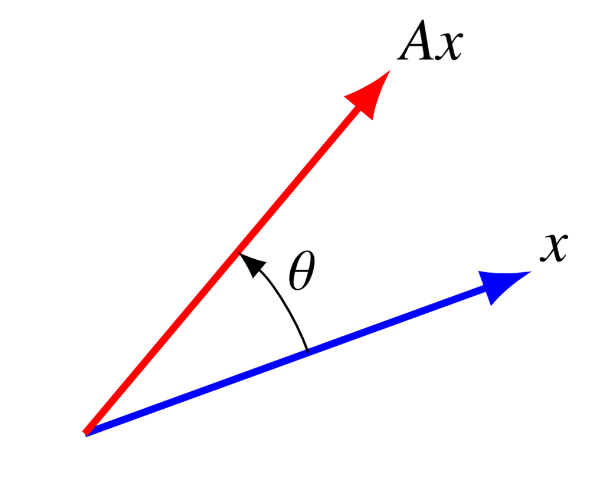

$\color{#003660}{\text{In Python}}$:

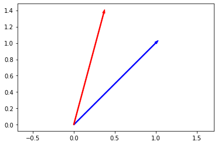

```python
x = np.array([1, 1])
import matplotlib.pyplot as plt

plt.arrow(0, 0, x[0], x[1], width=0.01, color="blue");

theta = np.pi / 6
R = np.array([[np.cos(theta), - np.sin(theta)], [np.sin(theta), np.cos(theta)]])
y = R @ x
plt.arrow(0, 0, y[0], y[1], width=0.01, color="red")
plt.axis("equal");
```

# (Social) graphs as matrices

Any (social network) graph with $n$ nodes can be represented by $n \times n$ matrix $A$, called adjacency matrix and defined as:

$$A_{ij} = \left\{ \begin{matrix} 1 \quad \text{if node $i$ points to node $j$}\\ 0 \quad \text{otherwise} \end{matrix}\right.$$

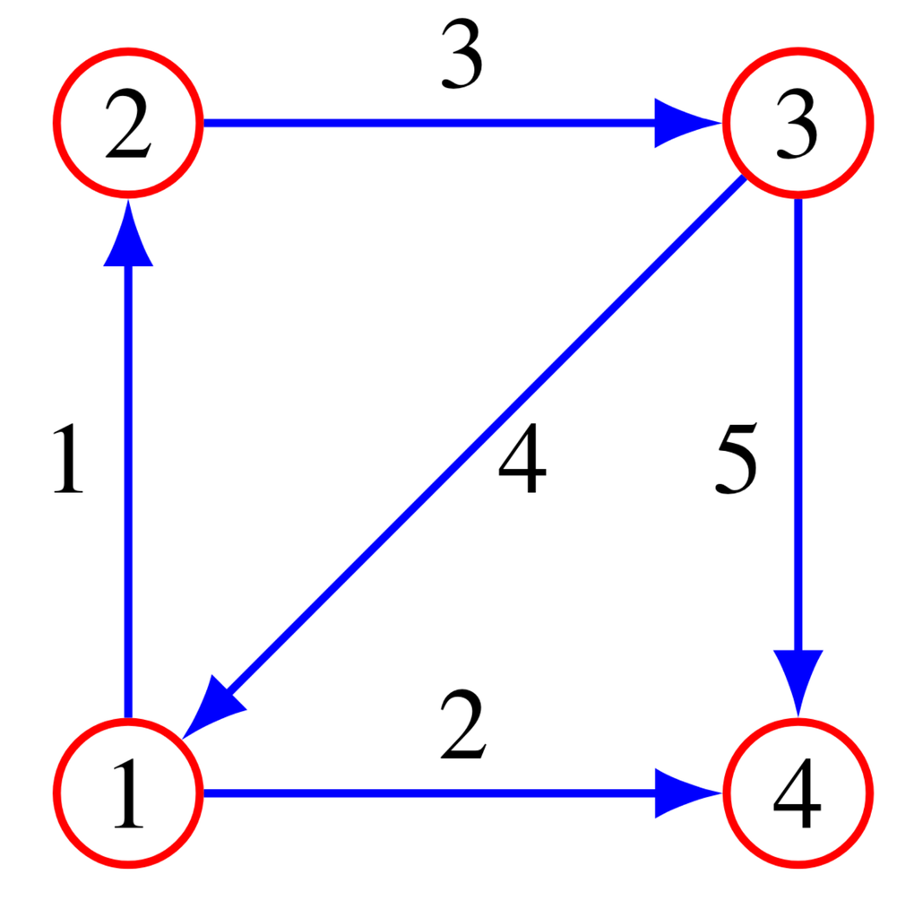

$\color{#047C91}{\text{Exercise}}$: Compute the adjacency matrix associated to this graph.

# Deep Learning

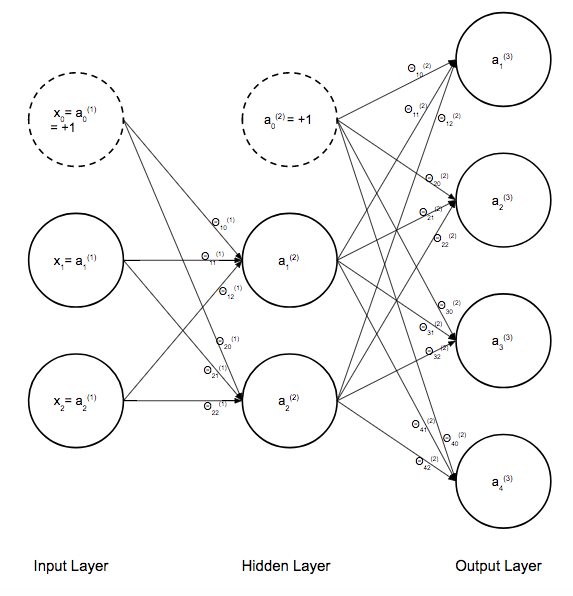

By writing $a^{(1)}$ the vector of the first layer, and $a^{(2)}$ the vector of the second layer, we see that: $$a^{(2)} = Wa^{(1)},$$ where $W_{ij}$ is the weight on the edge going from the $j$th element of the first layer $a^{(1)}_j$ to the $i$th element of the second layer $a^{(2)}_i$.

$\color{#003660}{\text{In Python}}$, we can implement the layer of a neural network.

```python
def simple_nn(input_x, weights):
    return weights @ input_x
```

# Outline: 06 Matrices

- Matrices
- Matrix-vector multiplication
- Examples

Resources: ILA, Ch. 6, 7.